# Kiểm định và xây dựng mô hình dự đoán trong các tập dữ liêu Ung Thư Vú (Breast Cancer)

Nhom10 - Ung Thư Vú (Breast Cancer)

2023-12-23

# Bảng phân công nhiệm vụ

| STT | Mã SV | Họ và tên | Nhiệm vụ |
| --- | --- | --- | --- |
| 1 | 21133013 | Đỗ Ngọc Chí Công | - Tiền xử lý dữ liệu kiểm tra có giá trị na hay không; và chuyển chuỗi thành số cho hai tập dữ liệu. - Vẽ biểu pie thể hiện tỷ trọng cho các giá trị cho các thuộc tính cho tập dữ liệu đầu tiên. Vẽ biể… |
| 2 | 21133059 | Trần Sĩ Nguyên | - Vẽ các biểu đồ: Thống kế thời gian sống kể từ mắc bệnh theo tình trạng hôn nhân của những bênh nhân tử vong Thống kế thời gian sống kể từ mắc bệnh theo màu da của những bênh nhân tử vong . Giải quyế… |
| 3 | 21133006 | Phan Cao Bằng | - Vẽ các biểu đồ: Biều đồ phân phối của trạng thái (Survived và Died) dưới sự ảnh hưởng của biến T.Stage và Age (Stacked Bar Chart). Biều đồ so sánh sự chệnh lệch của các trạng thái (Status) và thể hi… |
| 4 | 21133031 | Huỳnh Gia Hân | - Tìm hiểu dữ liệu - Vẽ biểu đồ thể hiện bán kính khối u, bán kinh sai số chuẩn khối u và bán kinh lớn nhất mà khối u có thể đạt được cho tập dữ liệu thứ hai (histogram). - Vẽ biểu đồ thể hiện sự tươn… |

# Phần 1. Tóm tắt:

- Kiểm định và xây dựng mô hình dự đoán trong các tập dữ liêu Ung Thư Vú (Breast Cancer)
- Giới thiệu các tập dữ liệu được sử dụng: Ung thư vú của SEER và Breast Cancer Wisconsin (Diagnostic)
- Trích xuất dữ liệu.
- Tiền xử lý dữ liệu:
  - Kiểm tra giá trị NA.
  - Ánh xạ và cập nhật dữ liệu thành số.
- Trực quan hóa dữ liệu: Vẽ các biểu đồ Box plot, Scatter plot, Stacked Bar Chart, Bar chart, Heatmap, Pie chart, Histogram, Bubble Chart.
- Thực hiện các bài toán kiểm định bằng ANOVA.
- Sử dụng các mô hình (Hồi quy Logarit, Decision Tree, Random Forest) thực hiện bài toán dự đoán.

# Phần 2. Giới thiệu:

- Ung thư vú là một trong những loại ung thư phổ biến nhất ở phụ nữ trên khắp thế giới. Nó xuất phát từ các tế bào trong vùng vú và có thể phát triển thành các khối u gọi là tuyến vú. Nếu không phát hiện và điều trị kịp thời, ung thư vú có thể lan rộ và gây hậu quả nặng nề cho sức khỏe. Đề tài nghiên cứu về ung thư vú là rất quan trọng vì nó đề cập đến nhiều khía cạnh quan trọng như nhận biết, chẩn đoán, và điều trị bệnh. Nghiên cứu trong lĩnh vực này có thể giúp cải thiện phương pháp chẩn đoán sớm, đề xuất các chiến lược điều trị hiệu quả hơn, và nâng cao chất lượng cuộc sống của những người mắc bệnh. Dữ liệu đồ án của chúng em chứa thông tin về nhiều yếu tố liên quan đến bệnh ung thư vú, bao gồm tuổi, chủng tộc, tình trạng hôn nhân, giai đoạn của bệnh, độ lợi tức (differentiation), kích thước u, tình trạng hormone (estrogen và progesterone), số nút cục bộ đã được kiểm tra, số nút cục bị nhiễm và thời gian sống. Việc phân tích dữ liệu này có thể mang lại thông tin quý báu về mối quan hệ giữa các yếu tố này và tỉ lệ sống sót, từ đó giúp cải thiện hiểu biết và phương pháp điều trị của bệnh ung thư vú. Mục tiêu của đề tài có thể bao gồm việc tìm kiếm mối liên quan giữa các biến số như tuổi, giai đoạn của bệnh, và các yếu tố khác với thời gian sống sót. Ngoài ra, nghiên cứu cũng có thể tập trung vào việc xây dựng mô hình dự đoán sống sót dựa trên các thông tin đặc trưng của bệnh nhân. Bằng cách áp dụng các kiến thức đã học ở môn lập trình R như kiểm định gải thuyết thống kê để tìm hiểu xem Estrogen status có ảnh hưởng đến Tumor size hay không? Cùng với đó Estrogen status có ảnh hưởng đến 6thStage? Hay 6thStage có ảnh hưởng đến Survival Months. Bên cạnh đó còn có các kiến thức như Kiểm định Logarit Dự đoán Sống hoặc Chết của người bệnh Ung thư vú dựa vào các nhân tố như Tuổi, Chủng tộc, Tình trạng Es/Pro và một số nhân tố khác có trong tệp dữ liệu. Chúng em còn xây dựng mô hình Cây Quyết Định để dự đoán Status(Dead or Alive) dựa trên Age,Estrogen.Status, X6th.Stage, Survival.Months. Ngoài ra, đồ án còn muốn bao quát thêm nhiều tác nhân khác ảnh hưởng đến ung thư vú nên chúng em đã đưa vào đồ án các thông tin khác như chuẩn đoán lành tính hay ác tính của tế bào ung thư, trung bình khoảng cách từ tâm đến các điểm trên chu vi, độ lệch chuẩn của giá trị mức xám, kích thước trung bình của tâm u, Diện tích trung bình của tâm u,….. Cùng với đó là xây dựng mô hình Random Forest dự đoán khối u là lành tính hay ác tính thông qua các chỉ số có trong tập dữ liệu, giúp phát hiện sớm u ác tính hay lành tính và phân loại các trường hợp ung thư vú. Thông qua việc nghiên cứu này, hy vọng sẽ có thêm thông tin quan trọng để hỗ trợ quá trình quyết định chẩn đoán và điều trị bệnh ung thư vú, từ đó cải thiện chất lượng cuộc sống của bệnh nhân và giảm thiểu tác động tiêu cực của bệnh lý này đối với xã hội.

# Phần 3. Thông tin về các tập dữ liệu:

### 3.1. Ung thư vú của SEER.

https://www.kaggle.com/datasets/reihanenamdari/breast-cancer

- Tập dữ liệu về bệnh nhân ung thư vú này được lấy từ bản cập nhật tháng 11 năm 2017 của Chương trình SEER của NCI, nơi cung cấp thông tin về thống kê ung thư dựa trên dân số. Bộ dữ liệu liên quan đến các bệnh nhân nữ bị ung thư vú ung thư biểu mô ống xâm nhập và ung thư biểu mô tiểu thùy (SEER trích dẫn chính mã lại mã mô học NOS 8522/3) được chẩn đoán vào năm 2006-2010. Những bệnh nhân có kích thước khối u không rõ, LN khu vực được kiểm tra, LN khu vực dương tính và những bệnh nhân có tháng sống sót dưới 1 tháng đã bị loại trừ. Và, 4024 bệnh nhân cuối cùng đã được đưa vào.
- Age: Độ tuổi.
- Race: Chủng tộc.
- Marital State: Tình trạng kết hôn.
- T Stage:
  - Giai đoạn T trong ung thư vú đề cập đến kích thước và mức độ lan rộng của khối u nguyên phát và là thành phần quan trọng của hệ thống phân giai đoạn TNM được sử dụng để xác định giai đoạn tổng thể của bệnh. T1 (Tumor size 1): Khối u có kích thước tối đa là 2 centimet (cm) trong chiều lớn nhất. T2 (Tumor size 2): Khối u có kích thước từ 2 cm đến 5 cm trong chiều lớn nhất. T3 (Tumor size 3): Khối u có kích thước lớn hơn 5 cm trong chiều lớn nhất. T4 (Tumor size 4): Có thể được chia thành các phụ giai đoạn T4a, T4b, T4c, và T4d: T4a: Khối u lan ra ngoài vú, nhưng không tác động lên cơ bắp hoặc da. T4b: Khối u lan ra ngoài vú và tác động lên cơ bắp. T4c: Khối u lan ra ngoài vú và tác động lên da, có thể bao gồm sưng, đau, và vẻ ngoại hình bất thường của da. T4d: Mọi giai đoạn của T4 có thể bao gồm sự lan truyền đến nút lymph cục.
- N Stage:
  - Giai đoạn N trong ung thư vú đề cập đến sự liên quan của các hạch bạch huyết ở nách (nách) và các khu vực khác gần vú, đồng thời đóng vai trò quan trọng trong việc xác định giai đoạn tổng thể và tiên lượng của bệnh. Trong hệ thống phân loại giai đoạn ung thư vú theo AJCC 6th, giá trị N (Node) chỉ ra mức độ lan truyền của ung thư đến các nút lymph cục xung quanh. Dưới đây là mô tả tổng quan về các giá trị N: N1 (Node 1): Sự lan truyền đến một hoặc nhiều nút lymph cục cục bộ. N2 (Node 2): Sự lan truyền có thể bao gồm một trong các điều kiện sau: Sự lan truyền đến 4-9 nút lymph cục cục bộ. Sự lan truyền đến nút lymph cục xa cách vú, nhưng không phải là nút lymph cục bên đối diện. N3 (Node 3): Sự lan truyền có thể bao gồm một trong các điều kiện sau: Sự lan truyền đến 10 nút lymph cục cục bộ trở lên. Sự lan truyền đến nút lymph cục bên đối diện của vú.
- 6th Stage:
  - Giai đoạn của ung thư vú theo hệ thống AJCC 6th được biểu diễn bằng các pha từ I đến IV, với mỗi giai đoạn được chia thành các phụ giai đoạn A, B, C, v.v., tùy thuộc vào một số yếu tố như kích thước của khối u, sự lan truyền đến nút lymph, và sự lan truyền đến các bộ phận khác của cơ thể. Các giá trị: IIA (Stage IIA): Đây là một giai đoạn trong hệ thống AJCC 6th và thường ám chỉ một mức độ lan truyền ở mức độ trung bình. Các yếu tố như kích thước của khối u và sự lan truyền đến nút lymph có thể đặc trưng cho giai đoạn này. IIB (Stage IIB): Giai đoạn này thường ám chỉ một mức độ lan truyền ở mức độ cao hơn so với IIA. Điều này có thể bao gồm các yếu tố như kích thước lớn hơn của khối u hoặc sự lan truyền đến nút lymph xa hơn. IIIA (Stage IIIA): Đây là một giai đoạn trong đó ung thư vú đã có mức độ lan truyền mạnh mẽ. Thông thường, các yếu tố như kích thước của khối u, sự lan truyền đến nút lymph cục, và vị trí của nút lymph cục bị ảnh hưởng đến việc xác định giai đoạn này. Ví dụ, giai đoạn IIIA có thể ám chỉ khối u lớn, có sự lan truyền đến nút lymph cục, nhưng không có sự lan truyền đến các cơ bản khác. IIIB (Stage IIIB): Giai đoạn IIIB thường ám chỉ một mức độ lan truyền mạnh mẽ hơn so với giai đoạn IIIA, nhưng không đạt đến mức độ lan truyền của giai đoạn IIIC. Các yếu tố như kích thước của khối u, sự lan truyền đến nút lymph cục, và vị trí của nút lymph cục có thể được xem xét để xác định giai đoạn này. IIIC (Stage IIIC): Đây là một giai đoạn nâng cao, trong đó sự lan truyền của ung thư đã mở rộng đến nút lymph cục xa và có thể liên quan đến các cơ bản lân cận khác. Giai đoạn IIIC thường là một giai đoạn nâng cao, chỉ ra một mức độ lan truyền rất mạnh mẽ của ung thư.
- Differentiate: Điều này đề cập đến mức độ trưởng thành của các tế bào khối u. Các tế bào biệt hóa tốt giống với tế bào vú bình thường và có tiên lượng tốt hơn, trong khi các tế bào kém biệt hóa thì bất thường và hung hãn hơn.
- Grade: Trong ung thư vú, thuật ngữ “độ” dùng để chỉ mức độ trưởng thành hoặc sự biệt hóa của các tế bào khối u. Về cơ bản, nó là thước đo mức độ giống nhau của các tế bào ung thư với các tế bào vú bình thường. Đánh giá tốc độ tế bào ung thư đang phân chia. Điểm số cụ thể từ mỗi đặc điểm này sau đó được cộng lại để xác định bậc độ tổng thể, theo các phân loại thông thường như Bậc độ 1 (tốt), Bậc độ 2 (trung bình), và Bậc độ 3 (kém). (Và nó có phân chia các trường hợp, mình sẽ tìm hiểu thêm.)
- A Stage: Có 2 giá trị: Regional - Một khối u đã lan rộng Distant - Một khối u đã lan đến các bộ phận của cơ thể ở xa
- Tumor Size: Kích thước khối u là yếu tố quan trọng quyết định giai đoạn và tiên lượng của bệnh ung thư vú. Nó được đo ở điểm rộng nhất và thường được báo cáo bằng milimét (mm) hoặc centimét (cm). (Nó cũng được chia ra các thành phần nhỏ hơn mình sẽ tìm hiểu sau.)
- Estrogren Status: Estrogen đóng một vai trò quan trọng trong sự phát triển và tiến triển của ung thư vú. Hiểu được tình trạng thụ thể estrogen (ER) của khối u là rất quan trọng để xác định các chiến lược điều trị hiệu quả nhất. Các thụ thể estrogen là các protein được tìm thấy trong tế bào vú. Khi estrogen liên kết với các thụ thể này, nó sẽ báo hiệu cho các tế bào phát triển và phân chia. Các khối u có số lượng thụ thể estrogen cao được gọi là dương tính với thụ thể estrogen (ER+). Những khối u này dựa vào estrogen để phát triển và có khả năng đáp ứng với các loại thuốc trị liệu bằng hormone ngăn chặn tác dụng của estrogen.
- Progesterone Status: Các thụ thể progesterone là các protein được tìm thấy trong một số tế bào vú. Khi progesterone liên kết với các thụ thể này, nó có thể thúc đẩy sự phát triển và phân chia tế bào. Các khối u có số lượng thụ thể progesterone cao được gọi là dương tính với thụ thể progesterone (PR+). Những khối u này có thể bị ảnh hưởng bởi progesterone và có khả năng đáp ứng với liệu pháp hormone nhắm vào cả estrogen và progesterone.
- Regional Node Examined: Trong ung thư vú, việc kiểm tra hạch vùng tùy thuộc vào giai đoạn và vị trí của khối u
- Reginol Node Positive
- Survival Months Status

### 3.2. Breast Cancer Wisconsin (Diagnostic).

https://www.kaggle.com/datasets/uciml/breast-cancer-wisconsin-data

- Các đặc điểm được tính toán từ hình ảnh số hóa của chọc hút bằng kim nhỏ (FNA) của khối vú. Chúng mô tả đặc điểm của nhân tế bào có trong hình ảnh. n không gian 3 chiều được mô tả trong: [K. P. Bennett và O. L. Mangasarian: “Phân biệt lập trình tuyến tính mạnh mẽ của hai tập hợp tuyến tính không thể tách rời”, Phương pháp tối ưu hóa và phần mềm 1, 1992, 23-34].

Attribute Information:

1. ID number
2. Diagnosis (M = malignant, B = benign) 3-32) Mười tính năng có giá trị thực được tính toán cho mỗi nhân tế bào:
- radius (mean of distances from center to points on the perimeter) - bán kính (trung bình khoảng cách từ tâm đến các điểm trên chu vi)
- texture (standard deviation of gray-scale values) - kết cấu (độ lệch chuẩn của các giá trị thang độ xám) Texture trong ung thư vú là một đặc trưng được sử dụng để phân tích biến đổi của các mẫu hình ảnh y tế. Để hiểu rõ hơn về texture, chúng ta có thể nói về độ lệch chuẩn (standard deviation) của các giá trị xám (gray-scale values). Trong hình ảnh y tế, các giá trị xám thường biểu thị mức độ sáng tối của các pixel. Độ lệch chuẩn là một chỉ số thống kê dùng để đo sự phân tán của dữ liệu. Trong trường hợp này, độ lệch chuẩn của các giá trị xám trong hình ảnh ung thư vú được sử dụng để đánh giá sự biến đổi trong mức độ sáng tối của các khu vực khác nhau trên hình ảnh. Thông thường, các vùng ung thư có xu hướng có texture không đều, không đồng nhất và thay đổi nhiều so với các vùng bình thường trong hình ảnh. Điều này có thể được phản ánh bằng độ lệch chuẩn lớn hơn của các giá trị xám trong các khu vực ung thư so với các khu vực bình thường.
- perimeter – Chu vi
- area – diện tích
- smoothness (local variation in radius lengths) - độ mịn (thay đổi cục bộ về độ dài bán kính) Smoothness (độ mịn) trong ung thư vú là một đặc trưng hình học được sử dụng để đánh giá sự biến thiên cục bộ trong độ dài bán kính của các vùng trong hình ảnh y tế của ung thư vú.

Để hiểu rõ hơn về smoothness, chúng ta có thể nói về sự biến thiên cục bộ trong độ dài bán kính của các vùng trong hình ảnh ung thư vú. Thông thường, trong ung thư vú, các vùng bất thường hoặc ung thư thường có xu hướng có độ biến thiên cục bộ cao hơn so với các vùng bình thường.

Smoothness được đo bằng cách xác định sự khác biệt giữa các bán kính của các vùng lân cận nhau. Nếu sự khác biệt này nhỏ, tức là các vùng có độ mịn cao, có xu hướng ít biến đổi và liền mạch hơn. Ngược lại, nếu sự khác biệt lớn, tức là các vùng có độ mịn thấp, có xu hướng biến đổi đột ngột và không liền mạch.

- compactness (perimeter^2 / area - 1.0) - nhỏ gọn (chu vi ^ 2 / diện tích - 1.0) Nếu một vùng có compactness gần với 0, điều đó cho thấy chu vi bình phương và diện tích của vùng tương đối tương đồng, tức là vùng đó có hình dạng gần như là một hình tròn hoặc hình vuông. Tuy nhiên, trong trường hợp ung thư vú, các vùng bất thường thường có compactness cao hơn. Điều này có nghĩa là chu vi bình phương của vùng lớn hơn đáng kể so với diện tích, cho thấy hình dạng của vùng không gọn gàng và có nhiều biến đổi.
- concavity (severity of concave portions of the contour) - lõm (mức độ nghiêm trọng của các phần lõm của đường viền) Concavity (độ lõm) trong ung thư vú là một đặc trưng hình học được sử dụng để đánh giá mức độ lõm của các phần lõm trên đường viền của một vùng trong hình ảnh y tế.

Để hiểu rõ hơn về concavity, chúng ta có thể xem xét cách đo lường mức độ lõm của các phần trên đường viền. Trong trường hợp ung thư vú, các phần lõm thường là các vùng không đều và không liền mạch trên đường viền của khối u. Concavity được sử dụng để đo lường mức độ lõm này, và thường được đánh giá dựa trên các đặc trưng hình học của đường viền của vùng.

- concave points (number of concave portions of the contour) - điểm lõm (số phần lõm của đường viền) Concave points (số lõm) trong ung thư vú là một đặc trưng hình học được sử dụng để đếm số lượng điểm lõm trên đường viền của một vùng trong hình ảnh y tế.

Để hiểu rõ hơn về concave points, chúng ta có thể xem xét cách đếm số lượng điểm lõm trên đường viền của một vùng. Trong trường hợp ung thư vú, các điểm lõm thường là các điểm trên đường viền của khối u mà có hình dạng lõm vào bên trong.

Số lượng concave points được sử dụng để đo lường mức độ lõm của đường viền và có thể cho thấy sự không đều và không liền mạch của vùng ung thư.

- symmetry – sự đối xứng
- fractal dimension (“coastline approximation” - 1) - kích thước fractal (“xấp xỉ đường bờ” - 1)

Fractal dimension (kích thước fraktal) trong ung thư vú là một đặc trưng hình học được tính dựa trên khái niệm “xấp xỉ đường bờ” của một vùng trong hình ảnh y tế.

Để hiểu rõ hơn về fractal dimension, chúng ta có thể xem xét cách xấp xỉ đường bờ của vùng. Trong trường hợp ung thư vú, đường bờ của vùng thường có hình dạng không đều, rối ren, và có nhiều chi tiết phức tạp.

Fractal dimension được tính bằng cách áp dụng khái niệm “xấp xỉ đường bờ” vào vùng. Đầu tiên, đường bờ của vùng được xem như đường bờ của một hình fraktal, trong đó các chi tiết nhỏ hơn được lặp lại trên các tỷ lệ khác nhau. Sau đó, fractal dimension được tính bằng cách áp dụng phương pháp tính toán kích thước fraktal vào đường bờ của vùng.

# Phần 4. Ung thư vú của SEER.

## 4.1. Trích xuất và đọc dữ liệu

- Trích xuất dữ liệu

```r
data <- read.csv("./Data/1_Breast_Cancer.csv")
datatable(data,filter = 'top', options = list(pageLength = 5, autoWidth = TRUE))
```

|  | Age | Race | Marital.Status | T.Stage | N.Stage | X6th.Stage | differentiate | Grade | A.Stage | Tumor.Size | Estrogen.Status | Progesterone.Status | Regional.Node.Examined | Reginol.Node.Positive | Survival.Months | Status |
| --- | --- | --- | --- | --- | --- | --- | --- | --- | --- | --- | --- | --- | --- | --- | --- | --- |
| 1 | 68 | White | Married | T1 | N1 | IIA | Poorly differentiated | 3 | Regional | 4 | Positive | Positive | 24 | 1 | 60 | Alive |
| 2 | 50 | White | Married | T2 | N2 | IIIA | Moderately differentiated | 2 | Regional | 35 | Positive | Positive | 14 | 5 | 62 | Alive |
| 3 | 58 | White | Divorced | T3 | N3 | IIIC | Moderately differentiated | 2 | Regional | 63 | Positive | Positive | 14 | 7 | 75 | Alive |
| 4 | 58 | White | Married | T1 | N1 | IIA | Poorly differentiated | 3 | Regional | 18 | Positive | Positive | 2 | 1 | 84 | Alive |
| 5 | 47 | White | Married | T2 | N1 | IIB | Poorly differentiated | 3 | Regional | 41 | Positive | Positive | 3 | 1 | 50 | Alive |
| 6 | 51 | White | Single | T1 | N1 | IIA | Moderately differentiated | 2 | Regional | 20 | Positive | Positive | 18 | 2 | 89 | Alive |
| 7 | 51 | White | Married | T1 | N1 | IIA | Well differentiated | 1 | Regional | 8 | Positive | Positive | 11 | 1 | 54 | Alive |
| 8 | 40 | White | Married | T2 | N1 | IIB | Moderately differentiated | 2 | Regional | 30 | Positive | Positive | 9 | 1 | 14 | Dead |
| 9 | 40 | White | Divorced | T4 | N3 | IIIC | Poorly differentiated | 3 | Regional | 103 | Positive | Positive | 20 | 18 | 70 | Alive |
| 10 | 69 | White | Married | T4 | N3 | IIIC | Well differentiated | 1 | Distant | 32 | Positive | Positive | 21 | 12 | 92 | Alive |

[output cut: 4014 more lines]

- Tóm tắt dữ liệu

```r
datatable(summary(data), options = list(pageLength = 5, autoWidth = TRUE))
```

|  | Var1 | Var2 | Freq |
| --- | --- | --- | --- |
|  |  | Age | Min. :30.00 |
|  |  | Age | 1st Qu.:47.00 |
|  |  | Age | Median :54.00 |
|  |  | Age | Mean :53.97 |
|  |  | Age | 3rd Qu.:61.00 |
|  |  | Age | Max. :69.00 |
|  |  | Race | Length:4024 |
|  |  | Race | Class :character |
|  |  | Race | Mode :character |
|  |  | Race |  |

[output cut: 86 more lines]

## 4.2. Tiền xử lý dữ liệu

- Sao chép dữ liệu để xử lý dữ liệu trên bản sao không gây ảnh hưởng đến dữ liệu gốc.

```r
data_temp<-data
df <- data
```

- Kiểm tra xem có tồn tại giá trị na không?

```r
if(length(data[is.na(data)])==0){
  print("Không tồn tại gía trị na")
}else{
  print("Tồn tại giá trị na")
}
```

```
## [1] "Không tồn tại gía trị na"
```

- Tiến hành lưu từng loại giá trị với cột giá trị tương ứng.

```r
Race_t<-c(sqldf("select distinct Race from data"))
Marital_Status_t<-c(sqldf("select distinct `Marital.Status` from data"))
T_Stage_t<-c(sqldf("select distinct `T.Stage` from data"))
N_Stage_t<-c(sqldf("select distinct `N.Stage` from data"))
X6th_Stage_t<-c(sqldf("select distinct `X6th.Stage` from data"))
differentiate_t<-c(sqldf("select distinct differentiate from data"))
Grade_t<-c(sqldf("select distinct Grade from data"))
A_Stage_t<-c(sqldf("select distinct `A.Stage` from data"))
Estrogen_Status_t<-c(sqldf("select distinct `Estrogen.Status` from data"))
Progesterone_Status_t<-c(sqldf("select distinct `Progesterone.Status` from data"))
Status_t<-c(sqldf("select distinct Status from data"))

list_data<- list(Race_t,Marital_Status_t,T_Stage_t,N_Stage_t,X6th_Stage_t,differentiate_t,Grade_t,A_Stage_t,Estrogen_Status_t,Progesterone_Status_t,Status_t)
```

- Tiến hành in ra các loại giá trị có trong từng cột.

```r
for(i in 1:length(list_data)){
  print(list_data[[i]])
}
```

```
## $Race
## [1] "White" "Black" "Other"
##
## $Marital.Status
## [1] "Married"   "Divorced"  "Single "   "Widowed"   "Separated"
##
## $T.Stage
## [1] "T1" "T2" "T3" "T4"
##
## $N.Stage
## [1] "N1" "N2" "N3"
##
## $X6th.Stage
## [1] "IIA"  "IIIA" "IIIC" "IIB"  "IIIB"
##
## $differentiate
## [1] "Poorly differentiated"     "Moderately differentiated"
## [3] "Well differentiated"       "Undifferentiated"
##
## $Grade
## [1] "3"                     "2"                     "1"
## [4] " anaplastic; Grade IV"
##
## $A.Stage
## [1] "Regional" "Distant"
##
## $Estrogen.Status
## [1] "Positive" "Negative"
##
## $Progesterone.Status
## [1] "Positive" "Negative"
##
## $Status
## [1] "Alive" "Dead"
```

- Ánh xạ và cập nhật dữ liệu chữ thành số.
- Ánh xạ dữ liệu

```r
data_copy <- data
AnhXa<-function (object,dk=""){
  name_c<-names(object)
  object_sp <- str_split(object[[1]]," ")
  for(i in 1:length(object_sp)){
    if(length(object_sp[[i]])>1){
      object_sp[i]<-str_remove(object_sp[[i]],"\" ")
      object_sp[i]<-paste(object_sp[i],"")
    }
    object_sp[i]<-paste(object_sp[i],dk,sep='')
  }
  len <- length(object_sp)
  print(paste("Cập nhật giá trị cột",name_c))
  print(object[[1]])
  print("Các giá trị tương ứng")
  print(1:len)
  print("------------------------------------")
  #update
  for(i in 1:len){
    query <- paste("update data_copy set ",paste("`",name_c,"`",sep=''),"=",i,"where ",paste("`",name_c,"`",sep=''),"=",str_replace(paste("'",object_sp[i],"'",sep=''),"\"c",""))
    data_copy <- sqldf(c(query, "select * from data_copy"))
  }
  data_copy
}
for(i in 1:length(list_data)){
  if(i!=6){
    data_copy<-AnhXa(list_data[[i]])
  }else{
    data_copy<-AnhXa(list_data[[i]],"differentiated")
  }
}
```

```
## [1] "Cập nhật giá trị cột Race"
## [1] "White" "Black" "Other"
## [1] "Các giá trị tương ứng"
## [1] 1 2 3
## [1] "------------------------------------"
## [1] "Cập nhật giá trị cột Marital.Status"
## [1] "Married"   "Divorced"  "Single "   "Widowed"   "Separated"
## [1] "Các giá trị tương ứng"
## [1] 1 2 3 4 5
## [1] "------------------------------------"
## [1] "Cập nhật giá trị cột T.Stage"
## [1] "T1" "T2" "T3" "T4"
## [1] "Các giá trị tương ứng"
## [1] 1 2 3 4
## [1] "------------------------------------"
```

[output cut: 42 more lines]

- Cập nhật dữ liệu chữ số thành số.

```r
name_c<-colnames(data_copy)
for(i in 1:length(name_c)){
  data_copy[name_c[i]]<-list(as.integer(unlist(data_copy[name_c[i]])))
}
datatable(data_copy,filter = 'top', options = list(pageLength = 5, autoWidth = TRUE))
```

|  | Age | Race | Marital.Status | T.Stage | N.Stage | X6th.Stage | differentiate | Grade | A.Stage | Tumor.Size | Estrogen.Status | Progesterone.Status | Regional.Node.Examined | Reginol.Node.Positive | Survival.Months | Status |
| --- | --- | --- | --- | --- | --- | --- | --- | --- | --- | --- | --- | --- | --- | --- | --- | --- |
| 1 | 68 | 1 | 1 | 1 | 1 | 1 | 1 | 3 | 1 | 4 | 1 | 1 | 24 | 1 | 60 | 1 |
| 2 | 50 | 1 | 1 | 2 | 2 | 2 | 2 | 2 | 1 | 35 | 1 | 1 | 14 | 5 | 62 | 1 |
| 3 | 58 | 1 | 2 | 3 | 3 | 3 | 2 | 2 | 1 | 63 | 1 | 1 | 14 | 7 | 75 | 1 |
| 4 | 58 | 1 | 1 | 1 | 1 | 1 | 1 | 3 | 1 | 18 | 1 | 1 | 2 | 1 | 84 | 1 |
| 5 | 47 | 1 | 1 | 2 | 1 | 4 | 1 | 3 | 1 | 41 | 1 | 1 | 3 | 1 | 50 | 1 |
| 6 | 51 | 1 | 3 | 1 | 1 | 1 | 2 | 2 | 1 | 20 | 1 | 1 | 18 | 2 | 89 | 1 |
| 7 | 51 | 1 | 1 | 1 | 1 | 1 | 3 | 3 | 1 | 8 | 1 | 1 | 11 | 1 | 54 | 1 |
| 8 | 40 | 1 | 1 | 2 | 1 | 4 | 2 | 2 | 1 | 30 | 1 | 1 | 9 | 1 | 14 | 2 |
| 9 | 40 | 1 | 2 | 4 | 3 | 3 | 1 | 3 | 1 | 103 | 1 | 1 | 20 | 18 | 70 | 1 |
| 10 | 69 | 1 | 1 | 4 | 3 | 3 | 3 | 3 | 2 | 32 | 1 | 1 | 21 | 12 | 92 | 1 |

[output cut: 4014 more lines]

- Lưu biến dữ liệu:

```r
data_temp<-data #Lưu trữ đẻ tránh bị biến đổi
rows_with_null <- data[!complete.cases(data), ]
data_dead <- data[data$Status=='Dead',]
datatable(data_dead,filter = 'top', options = list(pageLength = 5, autoWidth = TRUE))
```

|  | Age | Race | Marital.Status | T.Stage | N.Stage | X6th.Stage | differentiate | Grade | A.Stage | Tumor.Size | Estrogen.Status | Progesterone.Status | Regional.Node.Examined | Reginol.Node.Positive | Survival.Months | Status |
| --- | --- | --- | --- | --- | --- | --- | --- | --- | --- | --- | --- | --- | --- | --- | --- | --- |
| 8 | 40 | White | Married | T2 | N1 | IIB | Moderately differentiated | 2 | Regional | 30 | Positive | Positive | 9 | 1 | 14 | Dead |
| 11 | 68 | White | Widowed | T1 | N1 | IIA | Moderately differentiated | 2 | Regional | 13 | Positive | Positive | 9 | 1 | 64 | Dead |
| 41 | 57 | White | Single | T3 | N3 | IIIC | Moderately differentiated | 2 | Regional | 70 | Positive | Positive | 12 | 12 | 42 | Dead |
| 47 | 42 | White | Married | T1 | N3 | IIIC | Moderately differentiated | 2 | Regional | 9 | Negative | Negative | 15 | 2 | 39 | Dead |
| 65 | 67 | White | Divorced | T1 | N1 | IIA | Moderately differentiated | 2 | Regional | 13 | Positive | Positive | 16 | 3 | 60 | Dead |
| 67 | 31 | White | Married | T3 | N3 | IIIC | Poorly differentiated | 3 | Regional | 70 | Positive | Positive | 23 | 23 | 44 | Dead |
| 72 | 64 | White | Married | T2 | N3 | IIIC | Poorly differentiated | 3 | Regional | 34 | Positive | Negative | 24 | 20 | 12 | Dead |
| 91 | 53 | White | Married | T3 | N1 | IIIA | Poorly differentiated | 3 | Regional | 60 | Positive | Positive | 8 | 1 | 91 | Dead |
| 93 | 63 | Other | Married | T2 | N2 | IIIA | Well differentiated | 1 | Regional | 26 | Positive | Positive | 5 | 4 | 87 | Dead |
| 94 | 45 | Other | Married | T2 | N3 | IIIC | Poorly differentiated | 3 | Regional | 25 | Positive | Positive | 21 | 16 | 40 | Dead |

[output cut: 606 more lines]

## 4.3. Hiển thị dữ liệu lên biểu đồ

- Thống kế thời gian sống kể từ mắc bệnh theo tình trạng hôn nhân của những bênh nhân tử vong

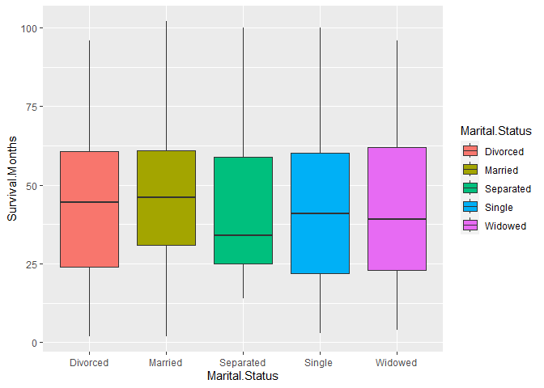

```r
ggplot(data_dead,aes(x=Marital.Status,y=Survival.Months,fill=Marital.Status))+
  geom_boxplot(outlier.colour="red")
```

- Thống kế thời gian sống kể từ mắc bệnh theo màu da của những bênh nhân tử vong

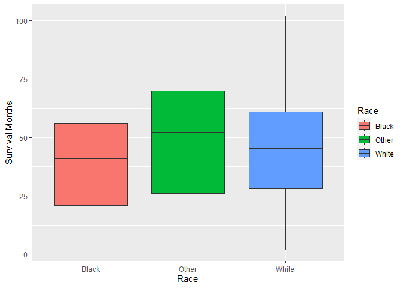

```r
ggplot(data_dead,aes(x=Race,y=Survival.Months,fill=Race))+
  geom_boxplot(outlier.colour="red")
```

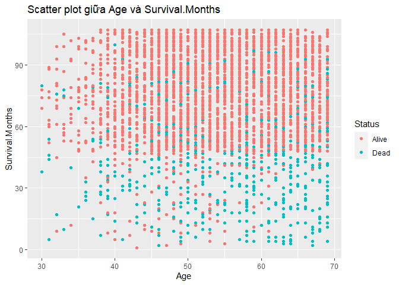

```r
# Scatter plot giữa Age và Survival.Months
ggplot(df, aes(x = Age, y = Survival.Months, color = Status)) +
  geom_point() +
  labs(title = "Scatter plot giữa Age và Survival.Months",
       x = "Age",
       y = "Survival.Months",
       color = "Status")
```

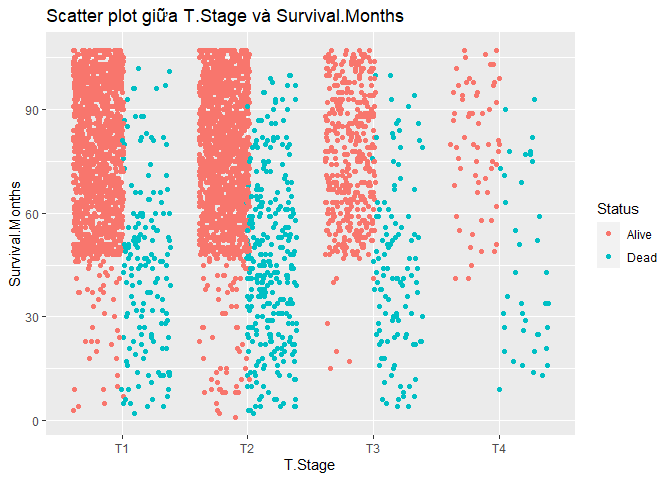

```r
# Scatter plot giữa T.Stage và Survival.Months
ggplot(df, aes(x = T.Stage, y = Survival.Months, color = Status)) +
  geom_point(position = position_jitterdodge()) +
  labs(title = "Scatter plot giữa T.Stage và Survival.Months",
       x = "T.Stage",
       y = "Survival.Months",
       color = "Status")
```

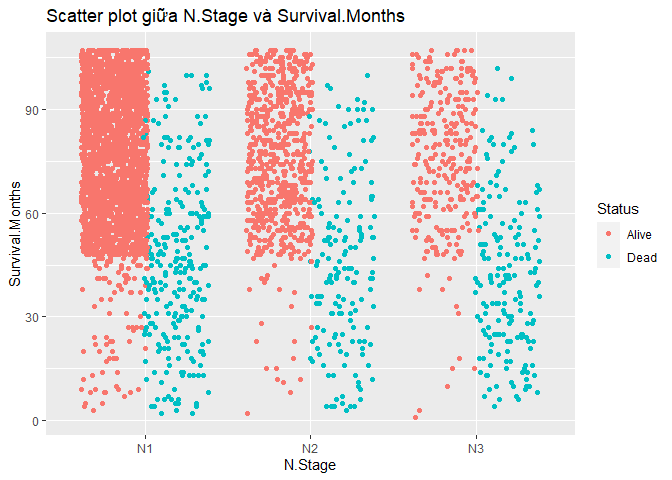

```r
# Scatter plot giữa N.Stage và Survival.Months
ggplot(df, aes(x = N.Stage, y = Survival.Months, color = Status)) +
  geom_point(position = position_jitterdodge()) +
  labs(title = "Scatter plot giữa N.Stage và Survival.Months",
       x = "N.Stage",
       y = "Survival.Months",
       color = "Status")
```

plot1: Scatter Plot thể hiện mối quan hệ của 2 biến Age, Survival.Months đồng thời thể hiện tình trạng Status giữa độ tuổi và thời gian sống. plot2,3: Mục đích của 2 đồ thị này có thể là để khám phá mối quan hệ giữa T.Stage/N.Stage và thời gian sống, cũng như so sánh sự chênh lệch giữa trạng thái.

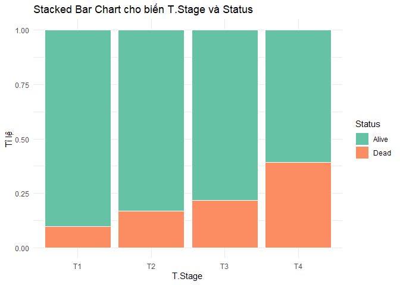

```r
# Biểu đồ stacked bar chart cho biến T.Stage và Status
ggplot(df, aes(x = T.Stage, fill = Status)) +
  geom_bar(position = "fill", color = "white") +
  labs(title = "Stacked Bar Chart cho biến T.Stage và Status",
       x = "T.Stage",
       y = "Tỉ lệ") +
  scale_fill_manual(values = c("#66c2a5", "#fc8d62"), name = "Status") +
  theme_minimal()
```

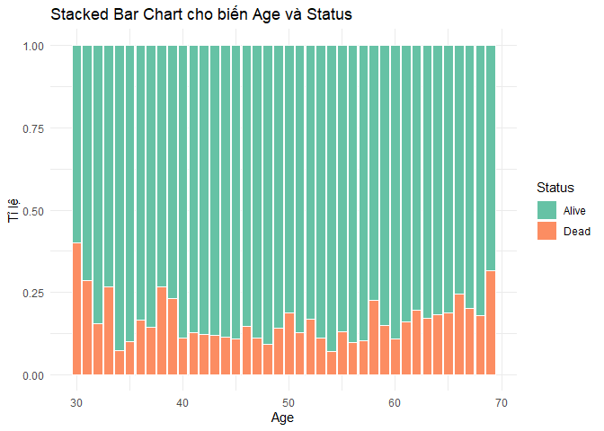

```r
# Biểu đồ stacked bar chart cho biến Age và Status
ggplot(df, aes(x = Age, fill = Status)) +
  geom_bar(position = "fill", color = "white") +
  labs(title = "Stacked Bar Chart cho biến Age và Status",
       x = "Age",
       y = "Tỉ lệ") +
  scale_fill_manual(values = c("#66c2a5", "#fc8d62"), name = "Status") +
  theme_minimal()
```

Cả hai biểu đồ stacked bar chart này giúp thấy rõ phân phối của trạng thái (Survived và Died) dưới sự ảnh hưởng của biến T.Stage và Age. Mỗi thanh bar biểu diễn một mức độ trạng thái, và màu sắc phản ánh trạng thái tương ứng.

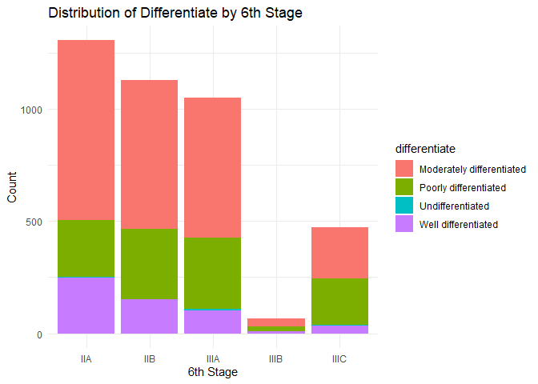

```r
ggplot(data, aes(x = X6th.Stage, fill = differentiate)) +
  geom_bar(position = "stack") +
  labs(title = "Distribution of Differentiate by 6th Stage",
       x = "6th Stage", y = "Count") +
  theme_minimal()
```

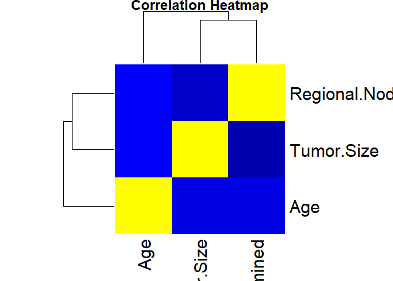

```r
correlation_matrix <- cor(data[, c("Age", "Tumor.Size", "Regional.Node.Examined")])
heatmap(correlation_matrix,
        col = colorRampPalette(c("blue", "black","yellow"))(20),
        main = "Correlation Heatmap")
```

- Biểu đồ Pie:

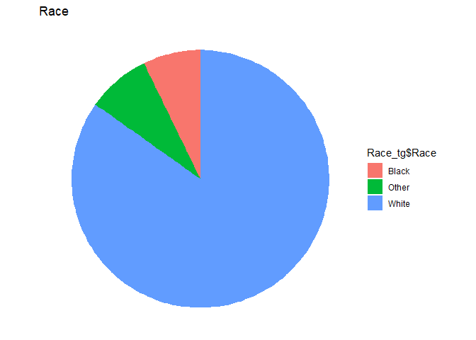

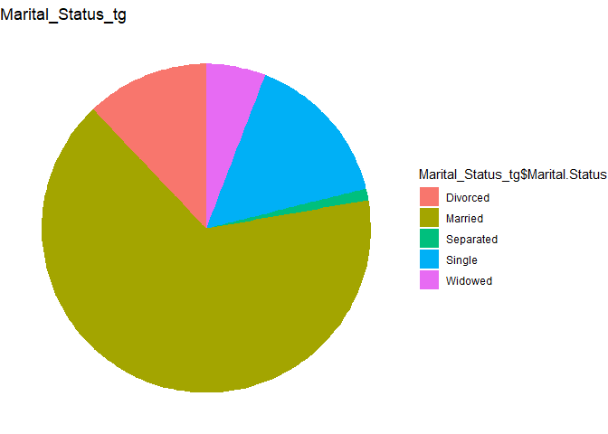

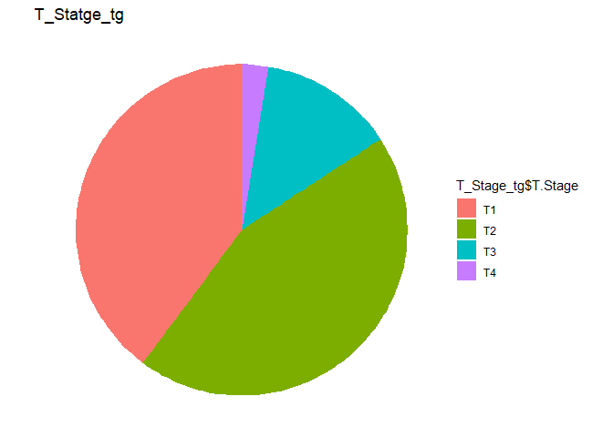

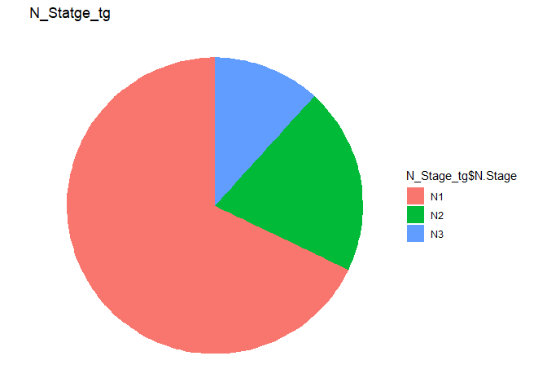

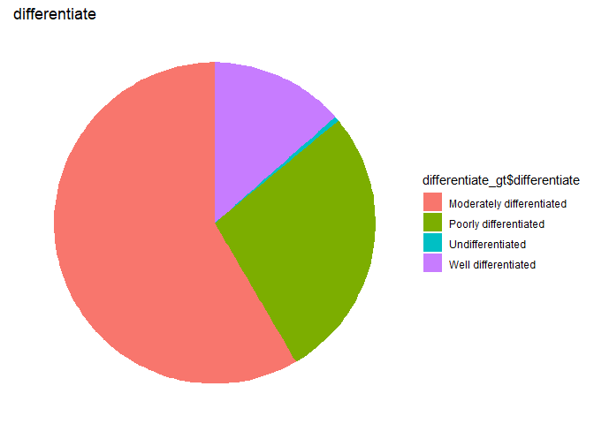

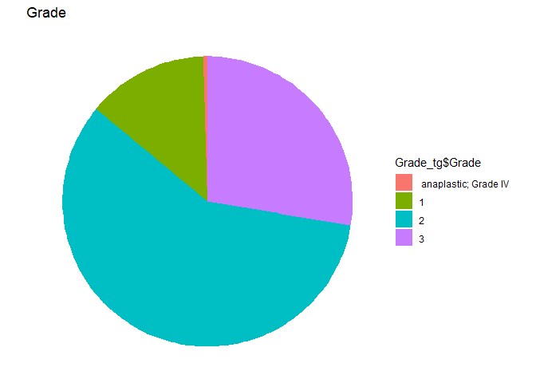

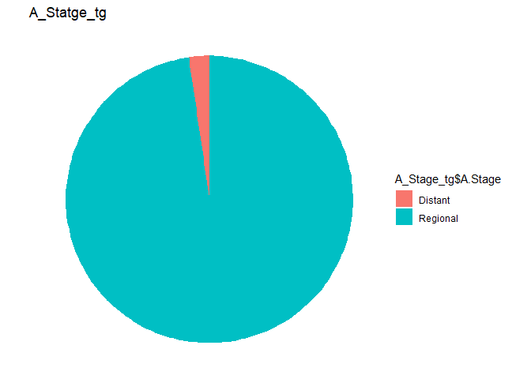

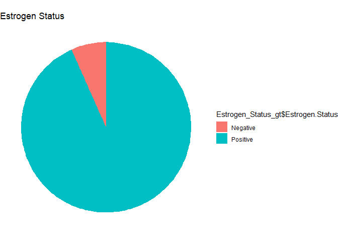

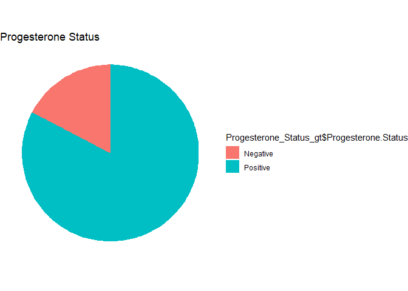

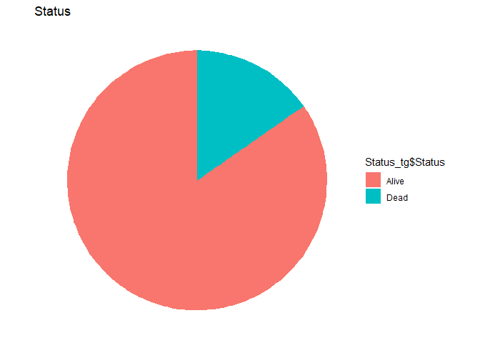

## 4.4. Bài toán.

### 4.4.1. Kiểm định giả thuyết:

#### a)Estrogen status có ảnh hưởng đến Tumor size?

- H0: Estrogen status không ảnh hưởng đến Tumor size  
- H1: Estrogen status ảnh hưởng đến Tumor size

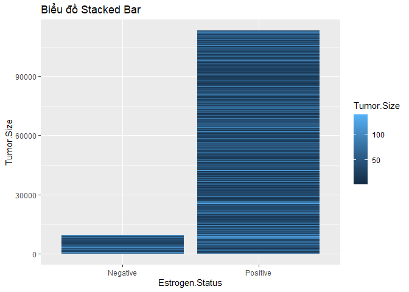

```r
# Vẽ biểu đồ ANOVA
ggplot(data, aes(x = Estrogen.Status, y = Tumor.Size, fill= Tumor.Size)) +
   geom_bar(stat = "identity") +
  labs(title = "Biểu đồ Stacked Bar",
       x = "Estrogen.Status",
       y = "Tumor.Size",
       fill = "Tumor.Size")
```

```r
# Sử dụng ANOVA
oneway <- aov(Tumor.Size ~ Estrogen.Status,data = data_copy)
summary(oneway)
```

```
##                   Df  Sum Sq Mean Sq F value   Pr(>F)
## Estrogen.Status    1    6371    6371   14.33 0.000156 ***
## Residuals       4022 1788054     445
## ---
## Signif. codes:  0 '***' 0.001 '**' 0.01 '*' 0.05 '.' 0.1 ' ' 1
```

- - Estrogen và tác động lên tế bào ung thư vú: Estrogen là một hormone nữ có vai trò quan trọng trong phát triển và duy trì tế bào trong vú. Khi có sự tăng cường hoạt động estrogen, nó có thể kích thích tế bào ung thư vú phát triển nhanh hơn và tăng kích thước của khối u.
- - Hormone estrogen và tăng trưởng mạch máu: Hormone estrogen có thể tác động đến quá trình tạo mạch máu và cung cấp dưỡng chất cho khối u ung thư vú. Khi estrogen được sản xuất hoặc tăng lên, nó có thể kích thích sự phát triển mạch máu xung quanh khối u, làm tăng cung cấp dưỡng chất và oxy cho tế bào ung thư vú, dẫn đến tăng kích thước của khối u.
- - Tác động của hormone estrogen trong điều trị: Hormone estrogen có thể ảnh hưởng đến hiệu quả của một số liệu trình điều trị trong ung thư vú, chẳng hạn như điều trị hormonal dựa trên estrogen (như tamoxifen) hoặc điều trị tiêu diệt hormone (như hormonotherapy). Nếu khối u ung thư vú phụ thuộc vào estrogen để phát triển, việc kiểm soát hoặc giảm hoạt động estrogen có thể ảnh hưởng đến kích thước của khối u.

#### b) Estrogen status có ảnh hưởng đến 6thStage?

- H0: Estrogen status không ảnh hưởng đến 6thStage  
- H1: Estrogen status ảnh hưởng đến 6thStage

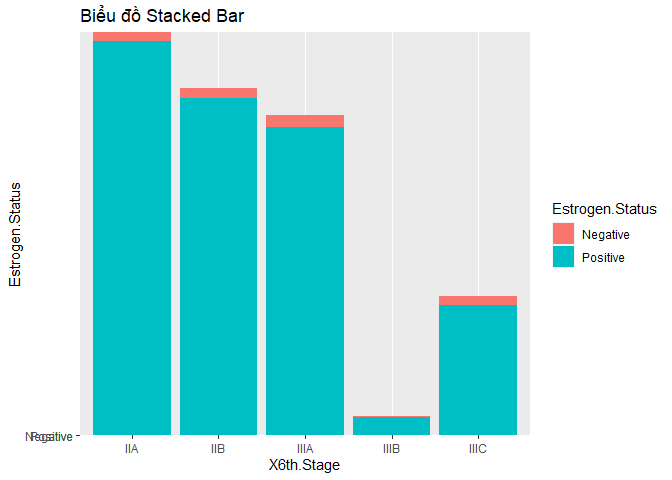

```r
# Vẽ biểu đồ ANOVA
ggplot(data, aes(x = X6th.Stage, y = Estrogen.Status, fill= Estrogen.Status)) +
   geom_bar(stat = "identity") +
  labs(title = "Biểu đồ Stacked Bar",
       x = "X6th.Stage",
       y = "Estrogen.Status",
       fill = "Estrogen.Status")
```

```r
oneway <- aov( X6th.Stage ~ Estrogen.Status, data = data_copy)
summary(oneway)
```

```
##                   Df Sum Sq Mean Sq F value  Pr(>F)
## Estrogen.Status    1     11  10.843   6.999 0.00819 **
## Residuals       4022   6231   1.549
## ---
## Signif. codes:  0 '***' 0.001 '**' 0.01 '*' 0.05 '.' 0.1 ' ' 1
```

* Trong trường hợp này, F value là khá cao (6.999) và p-value là rất thấp (0.00819 < 0.01). Điều này cho thấy có sự khác biệt có ý nghĩa thống kê giữa estrogen status và 6thStage. Nói cách khác, estrogen status có ảnh hưởng đến 6thStage. Do đó ta bác bỏ H0, Chấp nhận H1 - Estrogen status ảnh hưởng đến X6th.Stage

- Estrogen có tác động quan trọng đến sự phát triển và tiến triển của ung thư vú. Nó được biết đến là một yếu tố quan trọng trong việc tạo ra môi trường thuận lợi cho tế bào ung thư vú phát triển.
- Trong môi trường estrogen giàu, estrogen tương tác với các receptor estrogen trên tế bào ung thư vú, gây kích thích tế bào và thúc đẩy sự phân chia tế bào. Điều này có thể dẫn đến tăng tốc độ phát triển của khối u và sự lan truyền của tế bào ung thư vú. Trạng thái estrogen dương tính, nghĩa là có mức độ estrogen cao hoặc hoạt động của receptor estrogen tăng, có thể làm gia tăng nguy cơ ung thư vú phát triển và tiến triển đến các giai đoạn nâng cao như giai đoạn IIIB và IIIC trong hệ thống AJCC 6th.

#### c) 6thStage có ảnh hưởng đến Survival Months?

- H0: 6thStage không ảnh hưởng đến Survival Months  
- H1: 6thStage ảnh hưởng đến Survival Months

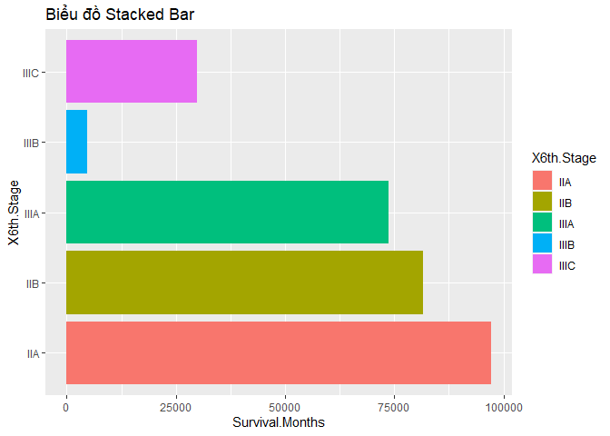

```r
# Vẽ biểu đồ ANOVA
ggplot(data, aes(x = Survival.Months, y = X6th.Stage, fill= X6th.Stage)) +
   geom_bar(stat = "identity") +
  labs(title = "Biểu đồ Stacked Bar",
       x = "Survival.Months",
       y = "X6th.Stage",
       fill = "X6th.Stage")
```

```r
oneway <- aov(Survival.Months ~ X6th.Stage, data = data_copy)
summary(oneway)
```

```
##               Df  Sum Sq Mean Sq F value   Pr(>F)
## X6th.Stage     1    6080    6080    11.6 0.000665 ***
## Residuals   4022 2107572     524
## ---
## Signif. codes:  0 '***' 0.001 '**' 0.01 '*' 0.05 '.' 0.1 ' ' 1
```

### 4.4.2. Bài toán: Tạo ra mô hình để kiểm tra các thuộc tính: Dự đoán Sống hoặc Chết của người bệnh Ung thư vú dựa vào các nhân tố như Tuổi, Chủng tộc, Tình trạng Es/Pro và một số nhân tố khác có trong tệp dữ liệu sử dụng hồi quy logistic.

```r
# Đọc dữ liệu từ dataframe (hoặc tạo dataframe từ dữ liệu)
df <- read.csv("./Data/1_Breast_Cancer.csv")
str(df)
```

```
## 'data.frame':    4024 obs. of  16 variables:
##  $ Age                   : int  68 50 58 58 47 51 51 40 40 69 ...
##  $ Race                  : chr  "White" "White" "White" "White" ...
##  $ Marital.Status        : chr  "Married" "Married" "Divorced" "Married" ...
##  $ T.Stage               : chr  "T1" "T2" "T3" "T1" ...
##  $ N.Stage               : chr  "N1" "N2" "N3" "N1" ...
##  $ X6th.Stage            : chr  "IIA" "IIIA" "IIIC" "IIA" ...
##  $ differentiate         : chr  "Poorly differentiated" "Moderately differentiated" "Moderately differentiated" "Poorly differentiated" ...
##  $ Grade                 : chr  "3" "2" "2" "3" ...
##  $ A.Stage               : chr  "Regional" "Regional" "Regional" "Regional" ...
##  $ Tumor.Size            : int  4 35 63 18 41 20 8 30 103 32 ...
##  $ Estrogen.Status       : chr  "Positive" "Positive" "Positive" "Positive" ...
##  $ Progesterone.Status   : chr  "Positive" "Positive" "Positive" "Positive" ...
##  $ Regional.Node.Examined: int  24 14 14 2 3 18 11 9 20 21 ...
##  $ Reginol.Node.Positive : int  1 5 7 1 1 2 1 1 18 12 ...
##  $ Survival.Months       : int  60 62 75 84 50 89 54 14 70 92 ...
##  $ Status                : chr  "Alive" "Alive" "Alive" "Alive" ...
```

```r
datatable(df,filter = 'top', options = list(pageLength = 5, autoWidth = TRUE))
```

|  | Age | Race | Marital.Status | T.Stage | N.Stage | X6th.Stage | differentiate | Grade | A.Stage | Tumor.Size | Estrogen.Status | Progesterone.Status | Regional.Node.Examined | Reginol.Node.Positive | Survival.Months | Status |
| --- | --- | --- | --- | --- | --- | --- | --- | --- | --- | --- | --- | --- | --- | --- | --- | --- |
| 1 | 68 | White | Married | T1 | N1 | IIA | Poorly differentiated | 3 | Regional | 4 | Positive | Positive | 24 | 1 | 60 | Alive |
| 2 | 50 | White | Married | T2 | N2 | IIIA | Moderately differentiated | 2 | Regional | 35 | Positive | Positive | 14 | 5 | 62 | Alive |
| 3 | 58 | White | Divorced | T3 | N3 | IIIC | Moderately differentiated | 2 | Regional | 63 | Positive | Positive | 14 | 7 | 75 | Alive |
| 4 | 58 | White | Married | T1 | N1 | IIA | Poorly differentiated | 3 | Regional | 18 | Positive | Positive | 2 | 1 | 84 | Alive |
| 5 | 47 | White | Married | T2 | N1 | IIB | Poorly differentiated | 3 | Regional | 41 | Positive | Positive | 3 | 1 | 50 | Alive |
| 6 | 51 | White | Single | T1 | N1 | IIA | Moderately differentiated | 2 | Regional | 20 | Positive | Positive | 18 | 2 | 89 | Alive |
| 7 | 51 | White | Married | T1 | N1 | IIA | Well differentiated | 1 | Regional | 8 | Positive | Positive | 11 | 1 | 54 | Alive |
| 8 | 40 | White | Married | T2 | N1 | IIB | Moderately differentiated | 2 | Regional | 30 | Positive | Positive | 9 | 1 | 14 | Dead |
| 9 | 40 | White | Divorced | T4 | N3 | IIIC | Poorly differentiated | 3 | Regional | 103 | Positive | Positive | 20 | 18 | 70 | Alive |
| 10 | 69 | White | Married | T4 | N3 | IIIC | Well differentiated | 1 | Distant | 32 | Positive | Positive | 21 | 12 | 92 | Alive |

[output cut: 4014 more lines]

- Một số thống kê mô tả về tập dữ liệu

```r
summary(df)
```

```
##       Age            Race           Marital.Status       T.Stage
##  Min.   :30.00   Length:4024        Length:4024        Length:4024
##  1st Qu.:47.00   Class :character   Class :character   Class :character
##  Median :54.00   Mode  :character   Mode  :character   Mode  :character
##  Mean   :53.97
##  3rd Qu.:61.00
##  Max.   :69.00
##    N.Stage           X6th.Stage        differentiate         Grade
##  Length:4024        Length:4024        Length:4024        Length:4024
##  Class :character   Class :character   Class :character   Class :character
##  Mode  :character   Mode  :character   Mode  :character   Mode  :character
##
##
##
##    A.Stage            Tumor.Size     Estrogen.Status    Progesterone.Status
##  Length:4024        Min.   :  1.00   Length:4024        Length:4024
##  Class :character   1st Qu.: 16.00   Class :character   Class :character
##  Mode  :character   Median : 25.00   Mode  :character   Mode  :character
##                     Mean   : 30.47
##                     3rd Qu.: 38.00
##                     Max.   :140.00
##  Regional.Node.Examined Reginol.Node.Positive Survival.Months
##  Min.   : 1.00          Min.   : 1.000        Min.   :  1.0
##  1st Qu.: 9.00          1st Qu.: 1.000        1st Qu.: 56.0
##  Median :14.00          Median : 2.000        Median : 73.0
##  Mean   :14.36          Mean   : 4.158        Mean   : 71.3
##  3rd Qu.:19.00          3rd Qu.: 5.000        3rd Qu.: 90.0
##  Max.   :61.00          Max.   :46.000        Max.   :107.0
##     Status
##  Length:4024
##  Class :character
##  Mode  :character
##
##
##
```

- Độ chính xác cơ bản

```r
table(df$Status)
```

```
##
## Alive  Dead
##  3408   616
```

```r
baseline <- round(3408/nrow(df),2) # tính toán giá trị cơ sở dựa trên số lượng đối tượng xác định là còn sống
baseline
```

```
## [1] 0.85
```

- Không chọn mô hình có độ chính xác thấp hơn mô hình cơ sở. Trong trường hợp này là 0,85
- Chuẩn bị dữ liệu

```r
# Đọc dữ liệu từ dataframe (hoặc tạo dataframe từ dữ liệu)
#df <- read.csv("./data/1_Breast_Cancer.csv")

# Chuyển thành factor
df$Race <- as.factor(df$Race)
df$Marital.Status <- as.factor(df$Marital.Status)
df$T.Stage <- as.factor(df$T.Stage)
df$N.Stage <- as.factor(df$N.Stage)
df$differentiate <- as.factor(df$differentiate)
df$Estrogen.Status <- as.factor(df$Estrogen.Status)
df$Progesterone.Status <- as.factor(df$Progesterone.Status)
df$X6th.Stage <- as.factor(df$X6th.Stage)
df$differentiate <- as.factor(df$differentiate)
df$Status <- as.factor(df$Status)
```

- Chia tập train và test

```r
# Chuyển thành số(1 for Dead, 0 for Alive)
df$Status <- ifelse(df$Status == "Dead", 1, 0)

set.seed(123)
splitIndex <- createDataPartition(df$Status, p = 0.75, list = FALSE)
train_data <- df[splitIndex, ]
test_data <- df[-splitIndex, ]
```

- Fit Model

```r
# Fit logistic regression model
model <- glm(Status ~ . -X6th.Stage - Grade , data = train_data, family = "binomial")

# Hiển thị model
summary(model)
```

```
##
## Call:
## glm(formula = Status ~ . - X6th.Stage - Grade, family = "binomial",
##     data = train_data)
##
## Coefficients:
##                                     Estimate Std. Error z value Pr(>|z|)
## (Intercept)                         1.348216   0.691827   1.949 0.051322 .
## Age                                 0.031413   0.007764   4.046 5.21e-05 ***
## RaceOther                          -0.890832   0.338443  -2.632 0.008485 **
## RaceWhite                          -0.462963   0.219824  -2.106 0.035199 *
## Marital.StatusMarried              -0.251065   0.192313  -1.305 0.191723
## Marital.StatusSeparated             0.337963   0.575832   0.587 0.557263
## Marital.StatusSingle               -0.164070   0.239656  -0.685 0.493594
## Marital.StatusWidowed              -0.026971   0.297436  -0.091 0.927749
## T.StageT2                           0.479479   0.176931   2.710 0.006729 **
## T.StageT3                           0.628506   0.363835   1.727 0.084087 .
## T.StageT4                           1.697288   0.441095   3.848 0.000119 ***
## N.StageN2                           0.262332   0.174991   1.499 0.133843
## N.StageN3                           0.170038   0.332478   0.511 0.609053
## differentiatePoorly differentiated  0.440036   0.143671   3.063 0.002193 **
## differentiateUndifferentiated       1.204651   0.920314   1.309 0.190549
## differentiateWell differentiated   -0.713124   0.246960  -2.888 0.003882 **
## A.StageRegional                     0.219423   0.380480   0.577 0.564142
## Tumor.Size                         -0.002560   0.005489  -0.466 0.640906
## Estrogen.StatusPositive            -0.454747   0.266438  -1.707 0.087866 .
## Progesterone.StatusPositive        -0.540311   0.177891  -3.037 0.002387 **
## Regional.Node.Examined             -0.029171   0.009214  -3.166 0.001546 **
## Reginol.Node.Positive               0.088340   0.020935   4.220 2.45e-05 ***
## Survival.Months                    -0.064780   0.003315 -19.543  < 2e-16 ***
## ---
## Signif. codes:  0 '***' 0.001 '**' 0.01 '*' 0.05 '.' 0.1 ' ' 1
##
## (Dispersion parameter for binomial family taken to be 1)
##
##     Null deviance: 2576.7  on 3017  degrees of freedom
## Residual deviance: 1642.5  on 2995  degrees of freedom
## AIC: 1688.5
##
## Number of Fisher Scoring iterations: 6
```

- Dự đoán kết quả dữ liệu trên tập Training

```r
PredictTrain <- predict(model, type = "response") # dự đoán xác suất xảy ra sự kiện cho mỗi quan sát trong tập Train
summary(PredictTrain)
```

```
##    Min. 1st Qu.  Median    Mean 3rd Qu.    Max.
## 0.00130 0.01948 0.05953 0.15242 0.17458 0.99617
```

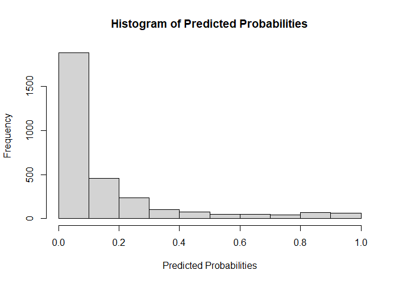

```r
hist(PredictTrain, main = "Histogram of Predicted Probabilities", xlab = "Predicted Probabilities")
```

- Tính toán dự đoán trung bình cho mỗi kết quả trong số hai kết quả

```r
# tính giá trị trung bình của dự đoán (xác suất dự đoán) dựa trên biến mục tiêu "Status" trong tập dữ liệu "Train"
tapply(PredictTrain, train_data$Status, mean)
```

```
##          0          1
## 0.09377671 0.47851992
```

- Xây dựng Confusion Matrix